# W5 STAT5003 RMD

Victor Z. Nygaard, vnyg7406

Last compiled on 28. januar, 2023

# 1.

We load in the required packages and data:

```r
data(PimaIndiansDiabetes2, package = "mlbench")
library(caret)
library(e1071) #SVMs
indians <- PimaIndiansDiabetes2
rm(PimaIndiansDiabetes2)
```

We inspect the data using `head`, `str`, `glimpse` and `summary`

```r
head(indians)
```

```
##   pregnant glucose pressure triceps insulin mass pedigree age diabetes
## 1        6     148       72      35      NA 33.6    0.627  50      pos
## 2        1      85       66      29      NA 26.6    0.351  31      neg
## 3        8     183       64      NA      NA 23.3    0.672  32      pos
## 4        1      89       66      23      94 28.1    0.167  21      neg
## 5        0     137       40      35     168 43.1    2.288  33      pos
## 6        5     116       74      NA      NA 25.6    0.201  30      neg
```

```r
str(indians)
```

```
## 'data.frame':    768 obs. of  9 variables:
##  $ pregnant: num  6 1 8 1 0 5 3 10 2 8 ...
##  $ glucose : num  148 85 183 89 137 116 78 115 197 125 ...
##  $ pressure: num  72 66 64 66 40 74 50 NA 70 96 ...
##  $ triceps : num  35 29 NA 23 35 NA 32 NA 45 NA ...
##  $ insulin : num  NA NA NA 94 168 NA 88 NA 543 NA ...
##  $ mass    : num  33.6 26.6 23.3 28.1 43.1 25.6 31 35.3 30.5 NA ...
##  $ pedigree: num  0.627 0.351 0.672 0.167 2.288 ...
##  $ age     : num  50 31 32 21 33 30 26 29 53 54 ...
##  $ diabetes: Factor w/ 2 levels "neg","pos": 2 1 2 1 2 1 2 1 2 2 ...
```

```r
glimpse(indians)
```

```
## Rows: 768
## Columns: 9
## $ pregnant <dbl> 6, 1, 8, 1, 0, 5, 3, 10, 2, 8, 4, 10, 10, 1, 5, 7, 0, 7, 1, 1…
## $ glucose  <dbl> 148, 85, 183, 89, 137, 116, 78, 115, 197, 125, 110, 168, 139,…
## $ pressure <dbl> 72, 66, 64, 66, 40, 74, 50, NA, 70, 96, 92, 74, 80, 60, 72, N…
## $ triceps  <dbl> 35, 29, NA, 23, 35, NA, 32, NA, 45, NA, NA, NA, NA, 23, 19, N…
## $ insulin  <dbl> NA, NA, NA, 94, 168, NA, 88, NA, 543, NA, NA, NA, NA, 846, 17…
## $ mass     <dbl> 33.6, 26.6, 23.3, 28.1, 43.1, 25.6, 31.0, 35.3, 30.5, NA, 37.…
## $ pedigree <dbl> 0.627, 0.351, 0.672, 0.167, 2.288, 0.201, 0.248, 0.134, 0.158…
## $ age      <dbl> 50, 31, 32, 21, 33, 30, 26, 29, 53, 54, 30, 34, 57, 59, 51, 3…
## $ diabetes <fct> pos, neg, pos, neg, pos, neg, pos, neg, pos, pos, neg, pos, n…
```

```r
summary(indians)
```

```
##     pregnant         glucose         pressure         triceps
##  Min.   : 0.000   Min.   : 44.0   Min.   : 24.00   Min.   : 7.00
##  1st Qu.: 1.000   1st Qu.: 99.0   1st Qu.: 64.00   1st Qu.:22.00
##  Median : 3.000   Median :117.0   Median : 72.00   Median :29.00
##  Mean   : 3.845   Mean   :121.7   Mean   : 72.41   Mean   :29.15
##  3rd Qu.: 6.000   3rd Qu.:141.0   3rd Qu.: 80.00   3rd Qu.:36.00
##  Max.   :17.000   Max.   :199.0   Max.   :122.00   Max.   :99.00
##                   NA's   :5       NA's   :35       NA's   :227
##     insulin            mass          pedigree           age        diabetes
##  Min.   : 14.00   Min.   :18.20   Min.   :0.0780   Min.   :21.00   neg:500
##  1st Qu.: 76.25   1st Qu.:27.50   1st Qu.:0.2437   1st Qu.:24.00   pos:268
##  Median :125.00   Median :32.30   Median :0.3725   Median :29.00
##  Mean   :155.55   Mean   :32.46   Mean   :0.4719   Mean   :33.24
##  3rd Qu.:190.00   3rd Qu.:36.60   3rd Qu.:0.6262   3rd Qu.:41.00
##  Max.   :846.00   Max.   :67.10   Max.   :2.4200   Max.   :81.00
##  NA's   :374      NA's   :11
```

We may remove rows containing `NA`s and correct the datatypes of `pregnant` and `age` to be integer,

```r
#indNA <- indians %>% subset(apply(indians, 1, anyNA))
#indNoNA2 <- indians %>% anti_join(indNA) %>% mutate(across(c(pregnant, age), as.integer))
indNoNA <- indians %>% drop_na() %>% mutate(across(c(pregnant, age), as.integer))
#identical(indNoNA2, indNoNA)
```

and plot the pairwise relations between the variables using `GGally`s `ggpairs`, noting that we add a small jitter to the point plots, in order to have less overlap:

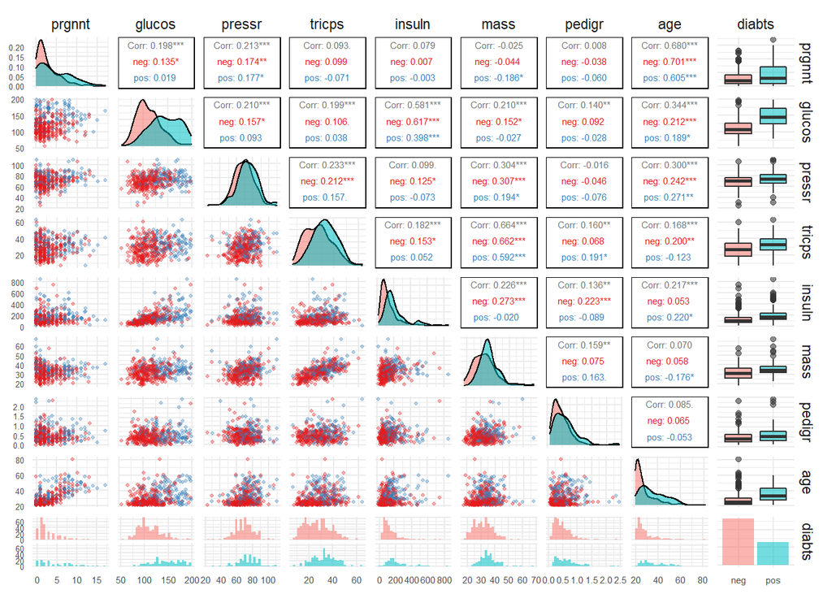

```r
library(GGally) #For pairwise plots
(ggp <- indNoNA %>% ggpairs(mapping = aes(alpha = 0.4, colour = diabetes), progress = F, columnLabels = abbreviate(colnames(indNoNA), 6),
                            upper = list(continuous = wrap("cor", size = 2)),
                            lower = list(continuous = wrap("points", size = 0.65, alpha = 0.35, position = position_jitter(w = 0.1, h = 0.15)))) +
      scale_colour_brewer(palette = "Set1")) +
   theme(axis.text.x = element_text(size = 5.5),
         axis.text.y = element_text(size = 5))
```

We note that the plot suggests colinearity amongst the NA-dropped data between `mass` and `triceps`, `insulin` and `glucose`, and between `pregnant` and `age`, of which the last two are immediately interpretable. Having grouped and coloured the data by whether they are positive for diabetes, is is even estimated that the correlation between glucose and insulin is signifigantly lower for positive test-subjects, than for negative test-subjects. We also have the immediately interpretable of `pregnant`-`age` correlation, as older women have had more time to have more kids. We may ponder the reasons for the calculated correlations amongst the other feature-pairs based on domain knowledge and looking through `?mlbench::PimaIndiansDiabetes2`.

# 2.

We implement the logistic regression for `diabetes` response, including all other features as predictors, and including these additively. We might note that by the above glimpses into the data, the first level of `diabetes` is `neg`, and thus the `success` probabilities will be in relation to ‘not `neg`’ which in our case is just `pos`, noting also that the canonically implemented link-function for `family = "binomial"` is the logit, by `? family`

```r
logmodel <- glm(diabetes ~ ., family = "binomial", data = indNoNA)
summary(logmodel)
```

```
##
## Call:
## glm(formula = diabetes ~ ., family = "binomial", data = indNoNA)
##
## Deviance Residuals:
##     Min       1Q   Median       3Q      Max
## -2.7823  -0.6603  -0.3642   0.6409   2.5612
##
## Coefficients:
##               Estimate Std. Error z value Pr(>|z|)
## (Intercept) -1.004e+01  1.218e+00  -8.246  < 2e-16 ***
## pregnant     8.216e-02  5.543e-02   1.482  0.13825
## glucose      3.827e-02  5.768e-03   6.635 3.24e-11 ***
## pressure    -1.420e-03  1.183e-02  -0.120  0.90446
## triceps      1.122e-02  1.708e-02   0.657  0.51128
## insulin     -8.253e-04  1.306e-03  -0.632  0.52757
## mass         7.054e-02  2.734e-02   2.580  0.00989 **
## pedigree     1.141e+00  4.274e-01   2.669  0.00760 **
## age          3.395e-02  1.838e-02   1.847  0.06474 .
## ---
## Signif. codes:  0 '***' 0.001 '**' 0.01 '*' 0.05 '.' 0.1 ' ' 1
##
## (Dispersion parameter for binomial family taken to be 1)
##
##     Null deviance: 498.10  on 391  degrees of freedom
## Residual deviance: 344.02  on 383  degrees of freedom
## AIC: 362.02
##
## Number of Fisher Scoring iterations: 5
```

We see from the summary that both the intercept and `glucose` are calculated to be strongly significant, with `mass` and `pedigree` being significant up to atleast a $\alpha = 0.01$ level. From the summary, we may also read off that four largest estimates (noting also that logit is increasing) were

```r
sort(summary(logmodel)$coef[,1], decreasing = T)[1:4]
```

```
##   pedigree   pregnant       mass    glucose
## 1.14090862 0.08215942 0.07053758 0.03826952
```

though both the significance levels and the precise level of the estimates can be critised, under the consideration of the implications of having simply removed missing data, and considering possible colinearity. We may also transform the estimates to ‘$p$-level’, using the inverse of the logit function

```r
logitInv <- function(x) {exp(x)/(1+exp(x))}
logitInv(summary(logmodel)$coef[,1])
```

```
##  (Intercept)     pregnant      glucose     pressure      triceps      insulin
## 4.358564e-05 5.205283e-01 5.095662e-01 4.996449e-01 5.028053e-01 4.997937e-01
##         mass     pedigree          age
## 5.176271e-01 7.578464e-01 5.084871e-01
```

We may evaluate the accuracy of the model on the training data, based on the $X\beta>0 = p\geq 0.5$ criteria as

```r
log_pred_class <- ifelse(predict(logmodel)>0, "pos", "neg") #predicting the class
mean(log_pred_class == indNoNA$diabetes) #the accuracy
```

```
## [1] 0.7831633
```

# 3.

With the `caret` package loaded, we may split the data,

```r
indTrainIndex <- createDataPartition(indNoNA$diabetes, p = 0.75, times = 1, list = F)
indTrain <- indNoNA[indTrainIndex,]
indTest <- indNoNA[-indTrainIndex,]
```

An alternative way of doing the splitting utilising `tidyverse` is

```r
indTrainTidy <- indNoNA %>%
  dplyr::group_by(diabetes) %>% #any number of variables you wish to partition by proportionally
  dplyr::slice_sample(prop = 0.75) # '.75' is the proportion of the original df you wish to sample
indTestTidy <- anti_join(indNoNA, indTrainTidy) # creates test dataframe with those observations not in 'train.'
```

[output not shown]

with the data seperated, we may use `caret` to train each of logistic regression, LDA, kNN and SVM across the training dataset, on the additive form.

```r
logTrainModel <- train(diabetes ~ .,
                     data = indTrain,
                     method = "glm", family = "binomial",
                     trControl = trainControl(method = "repeatedcv",
                                              repeats = 5))
ldaTrainModel <- train(diabetes ~ .,
                     data = indTrain,
                     method = "lda",
                     trControl = trainControl(method = "repeatedcv",
                                              repeats = 5))
knnTrainModel <- train(diabetes ~ .,
                     data = indTrain,
                     method = "knn",
                     trControl = trainControl(method = "repeatedcv",
                                              repeats = 5))
svmTrainModel <- train(diabetes ~ .,
                     data = indTrain,
                     method = "svmLinearWeights",
                     trControl = trainControl(method = "repeatedcv",
                                              repeats = 5))
```

We may take a look at the returned objects and a summary of each of these:

```r
logTrainModel
```

```
## Generalized Linear Model
##
## 295 samples
##   8 predictor
##   2 classes: 'neg', 'pos'
##
## No pre-processing
## Resampling: Cross-Validated (10 fold, repeated 5 times)
## Summary of sample sizes: 265, 265, 265, 265, 265, 265, ...
## Resampling results:
##
##   Accuracy   Kappa
##   0.7814253  0.473504
```

```r
summary(logTrainModel)
```

```
##
## Call:
## NULL
##
## Deviance Residuals:
##     Min       1Q   Median       3Q      Max
## -2.6529  -0.6490  -0.3614   0.6085   2.6303
##
## Coefficients:
##               Estimate Std. Error z value Pr(>|z|)
## (Intercept) -1.012e+01  1.397e+00  -7.245 4.33e-13 ***
## pregnant     8.362e-02  6.388e-02   1.309  0.19052
## glucose      3.787e-02  7.057e-03   5.366 8.03e-08 ***
## pressure     2.256e-03  1.494e-02   0.151  0.87998
## triceps      4.661e-03  1.919e-02   0.243  0.80809
## insulin     -1.574e-05  1.431e-03  -0.011  0.99122
## mass         6.265e-02  3.173e-02   1.975  0.04831 *
## pedigree     1.570e+00  5.158e-01   3.043  0.00234 **
## age          3.463e-02  2.121e-02   1.633  0.10253
## ---
## Signif. codes:  0 '***' 0.001 '**' 0.01 '*' 0.05 '.' 0.1 ' ' 1
##
## (Dispersion parameter for binomial family taken to be 1)
##
##     Null deviance: 375.08  on 294  degrees of freedom
## Residual deviance: 255.58  on 286  degrees of freedom
## AIC: 273.58
##
## Number of Fisher Scoring iterations: 5
```

```r
ldaTrainModel
```

```
## Linear Discriminant Analysis
##
## 295 samples
##   8 predictor
##   2 classes: 'neg', 'pos'
##
## No pre-processing
## Resampling: Cross-Validated (10 fold, repeated 5 times)
## Summary of sample sizes: 266, 266, 265, 265, 266, 265, ...
## Resampling results:
##
##   Accuracy   Kappa
##   0.7894745  0.4925324
```

```r
summary(ldaTrainModel)
```

```
##             Length Class      Mode
## prior        2     -none-     numeric
## counts       2     -none-     numeric
## means       16     -none-     numeric
## scaling      8     -none-     numeric
## lev          2     -none-     character
## svd          1     -none-     numeric
## N            1     -none-     numeric
## call         3     -none-     call
## xNames       8     -none-     character
## problemType  1     -none-     character
## tuneValue    1     data.frame list
## obsLevels    2     -none-     character
## param        0     -none-     list
```

```r
knnTrainModel
```

```
## k-Nearest Neighbors
##
## 295 samples
##   8 predictor
##   2 classes: 'neg', 'pos'
##
## No pre-processing
## Resampling: Cross-Validated (10 fold, repeated 5 times)
## Summary of sample sizes: 265, 266, 265, 266, 265, 266, ...
## Resampling results across tuning parameters:
##
##   k  Accuracy   Kappa
##   5  0.7043563  0.3012118
##   7  0.7400033  0.3777613
##   9  0.7610739  0.4276419
##
## Accuracy was used to select the optimal model using the largest value.
## The final value used for the model was k = 9.
```

```r
summary(knnTrainModel)
```

```
##             Length Class      Mode
## learn       2      -none-     list
## k           1      -none-     numeric
## theDots     0      -none-     list
## xNames      8      -none-     character
## problemType 1      -none-     character
## tuneValue   1      data.frame list
## obsLevels   2      -none-     character
## param       0      -none-     list
```

```r
svmTrainModel
```

```
## Linear Support Vector Machines with Class Weights
##
## 295 samples
##   8 predictor
##   2 classes: 'neg', 'pos'
##
## No pre-processing
## Resampling: Cross-Validated (10 fold, repeated 5 times)
## Summary of sample sizes: 265, 265, 265, 265, 267, 266, ...
## Resampling results across tuning parameters:
##
##   cost  weight  Accuracy   Kappa
##   0.25  1       0.7795977  0.4725986
##   0.25  2       0.7702102  0.5002074
##   0.25  3       0.7497947  0.4958022
##   0.50  1       0.7809770  0.4766388
##   0.50  2       0.7721658  0.5043541
##   0.50  3       0.7531773  0.5004564
##   1.00  1       0.7795731  0.4731530
##   1.00  2       0.7674762  0.4935825
##   1.00  3       0.7484187  0.4916785
##
## Accuracy was used to select the optimal model using the largest value.
## The final values used for the model were cost = 0.5 and weight = 1.
```

```r
summary(svmTrainModel)
```

```
##
## Call:
## svm.default(x = as.matrix(x), y = y, kernel = "linear", cost = param$cost,
##     class.weights = cwts, probability = classProbs)
##
##
## Parameters:
##    SVM-Type:  C-classification
##  SVM-Kernel:  linear
##        cost:  0.5
##
## Number of Support Vectors:  145
##
##  ( 72 73 )
##
##
## Number of Classes:  2
##
## Levels:
##  neg pos
```

```r
pred_logTrainModel <- predict(logTrainModel, newdata = indTest)
pred_ldaTrainModel <- predict(ldaTrainModel, newdata = indTest)
pred_knnTrainModel <- predict(knnTrainModel, newdata = indTest)
pred_svmTrainModel <- predict(svmTrainModel, newdata = indTest)
```

We may evaluate the accuracy of these models

```r
mean(pred_logTrainModel == indTest$diabetes) #log
```

```
## [1] 0.7835052
```

```r
mean(pred_ldaTrainModel == indTest$diabetes) #LDA
```

```
## [1] 0.7731959
```

```r
mean(pred_knnTrainModel == indTest$diabetes) #kNN
```

```
## [1] 0.7628866
```

```r
mean(pred_svmTrainModel == indTest$diabetes) #SVM
```

```
## [1] 0.7731959
```

Having calculated the test set accuracies above we note that the accuracies are rather similar with a standard deviation of just 0.0084175

We may do a confusion matrix overview of each of the models, and compare these:

```r
#?caret::confusionMatrix
caret::confusionMatrix(data = pred_logTrainModel, reference = indTest$diabetes, positive = "pos") #log
```

```
## Confusion Matrix and Statistics
##
##           Reference
## Prediction neg pos
##        neg  55  11
##        pos  10  21
##
##                Accuracy : 0.7835
##                  95% CI : (0.6883, 0.8607)
##     No Information Rate : 0.6701
##     P-Value [Acc > NIR] : 0.009833
##
##                   Kappa : 0.5064
##
##  Mcnemar's Test P-Value : 1.000000
##
##             Sensitivity : 0.6562
##             Specificity : 0.8462
##          Pos Pred Value : 0.6774
##          Neg Pred Value : 0.8333
##              Prevalence : 0.3299
##          Detection Rate : 0.2165
##    Detection Prevalence : 0.3196
##       Balanced Accuracy : 0.7512
##
##        'Positive' Class : pos
##
```

```r
caret::confusionMatrix(data = pred_ldaTrainModel, reference = indTest$diabetes, positive = "pos") #LDA
```

```
## Confusion Matrix and Statistics
##
##           Reference
## Prediction neg pos
##        neg  54  11
##        pos  11  21
##
##                Accuracy : 0.7732
##                  95% CI : (0.677, 0.8521)
##     No Information Rate : 0.6701
##     P-Value [Acc > NIR] : 0.01783
##
##                   Kappa : 0.487
##
##  Mcnemar's Test P-Value : 1.00000
##
##             Sensitivity : 0.6562
##             Specificity : 0.8308
##          Pos Pred Value : 0.6562
##          Neg Pred Value : 0.8308
##              Prevalence : 0.3299
##          Detection Rate : 0.2165
##    Detection Prevalence : 0.3299
##       Balanced Accuracy : 0.7435
##
##        'Positive' Class : pos
##
```

```r
caret::confusionMatrix(data = pred_knnTrainModel, reference = indTest$diabetes, positive = "pos") #kNN
```

```
## Confusion Matrix and Statistics
##
##           Reference
## Prediction neg pos
##        neg  55  13
##        pos  10  19
##
##                Accuracy : 0.7629
##                  95% CI : (0.6658, 0.8434)
##     No Information Rate : 0.6701
##     P-Value [Acc > NIR] : 0.03066
##
##                   Kappa : 0.4506
##
##  Mcnemar's Test P-Value : 0.67666
##
##             Sensitivity : 0.5938
##             Specificity : 0.8462
##          Pos Pred Value : 0.6552
##          Neg Pred Value : 0.8088
##              Prevalence : 0.3299
##          Detection Rate : 0.1959
##    Detection Prevalence : 0.2990
##       Balanced Accuracy : 0.7200
##
##        'Positive' Class : pos
##
```

```r
caret::confusionMatrix(data = pred_svmTrainModel, reference = indTest$diabetes, positive = "pos") #SVM
```

```
## Confusion Matrix and Statistics
##
##           Reference
## Prediction neg pos
##        neg  54  11
##        pos  11  21
##
##                Accuracy : 0.7732
##                  95% CI : (0.677, 0.8521)
##     No Information Rate : 0.6701
##     P-Value [Acc > NIR] : 0.01783
##
##                   Kappa : 0.487
##
##  Mcnemar's Test P-Value : 1.00000
##
##             Sensitivity : 0.6562
##             Specificity : 0.8308
##          Pos Pred Value : 0.6562
##          Neg Pred Value : 0.8308
##              Prevalence : 0.3299
##          Detection Rate : 0.2165
##    Detection Prevalence : 0.3299
##       Balanced Accuracy : 0.7435
##
##        'Positive' Class : pos
##
```

For which we see once again very similar results regarding sensitivity and specificity.

# 4.

We redo the logistic, kNN, and SVM models, now featuring only `mass` and `glucose` as additive predictors. We do this across the entire `NA`-omitted data `indNoNA` for illustration. Note that we use `method = svmRadial` for employing the radial kernel in the SVM model.

```r
logSmallModel <- train(diabetes ~ mass + glucose,
                     data = indNoNA,
                     method = "glm", family = "binomial",
                     trControl = trainControl(method = "repeatedcv",
                                              repeats = 5))
knnSmallModel <- train(diabetes ~ mass + glucose,
                     data = indNoNA,
                     method = "knn",
                     trControl = trainControl(method = "repeatedcv",
                                              repeats = 5))
svmSmallModel_lin <- train(diabetes ~ mass + glucose,
                     data = indNoNA,
                     method = "svmLinearWeights",
                     trControl = trainControl(method = "repeatedcv",
                                              repeats = 5))

library(kernlab)
svmSmallModel_rad <- train(diabetes ~ mass + glucose,
                     data = indNoNA,
                     method = "svmRadial",
                     trControl = trainControl(method = "repeatedcv",
                                              repeats = 5))
```

We may replot the plot of `mass` and `glucose` from the `ggpairs` plot, now in large format:

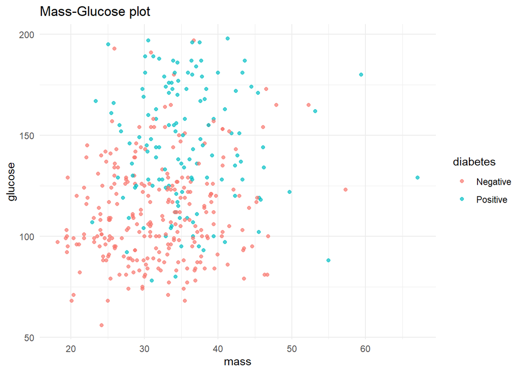

```r
(pMassGlu <- indNoNA %>% ggplot(mapping = aes(x = mass, y = glucose, colour = diabetes)) + geom_point(alpha = 0.7) + scale_colour_discrete(labels=c('Negative', 'Positive')) + labs(title = "Mass-Glucose plot"))
```

```r
#the coefficient estimates of logistic model
log_s_logit_coef <- as.numeric(summary(logSmallModel)$coef[,1])
(yint_log <- -log_s_logit_coef[1]/log_s_logit_coef[3])
```

```
## [1] 203.901
```

```r
(slo_log <- -log_s_logit_coef[2]/log_s_logit_coef[3])
```

```
## [1] -1.763398
```

```r
#svm parameters
(w <- t((svmSmallModel_lin$finalModel)$coefs) %*% (svmSmallModel_lin$finalModel)$SV)
```

```
##            mass    glucose
## [1,] -0.3632495 -0.9295865
```

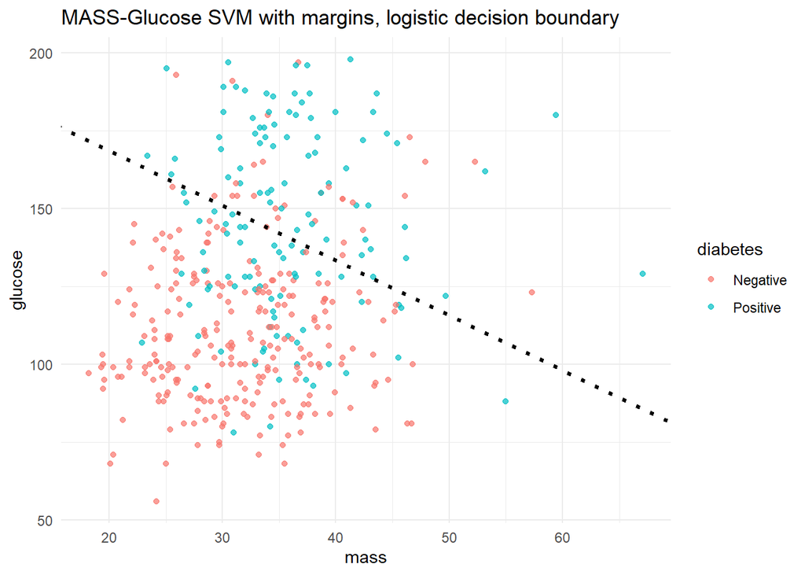

```r
beta_0_svm <- (svmSmallModel_lin$finalModel)$rho


pMassGlu +
   geom_abline(intercept = yint_log, slope = slo_log, size = 1.2,
               linetype = "dotted", colour = "black") +
   geom_abline(intercept = (-beta_0_svm-(svmSmallModel_lin$finalModel)$cost) / w[1, 2], slope = -w[1, 1] / w[1, 2], size = 5, linetype = "dashed", colour = "green") +
   geom_abline(intercept = (-beta_0_svm+(svmSmallModel_lin$finalModel)$cost) / w[1, 2], slope = -w[1, 1] / w[1, 2], size = 5, linetype = "dotted", colour = "black") +
   labs(title = "MASS-Glucose SVM with margins, logistic decision boundary")
```